# Collaboration and Competition

In this notebook, you will learn how to use the Unity ML-Agents environment for the third project of the [Deep Reinforcement Learning Nanodegree](https://www.udacity.com/course/deep-reinforcement-learning-nanodegree--nd893) program.

### 1. Start the Environment

We begin by importing the necessary packages. If the code cell below returns an error, please revisit the project instructions to double-check that you have installed [Unity ML-Agents](https://github.com/Unity-Technologies/ml-agents/blob/master/docs/Installation.md) and [NumPy](http://www.numpy.org/).

```python
# Watch for changes in any of the imported files
%load_ext autoreload
%autoreload 2

import torch
import numpy as np
from collections import deque
from unityagents import UnityEnvironment

import matplotlib.pyplot as plt
%matplotlib inline

from ddpg_agent import Agent
```

Next, we will start the environment! *Before running the code cell below*, change the `file_name` parameter to match the location of the Unity environment that you downloaded.

- **Mac**: `"path/to/Tennis.app"`
- **Windows** (x86): `"path/to/Tennis_Windows_x86/Tennis.exe"`
- **Windows** (x86_64): `"path/to/Tennis_Windows_x86_64/Tennis.exe"`
- **Linux** (x86): `"path/to/Tennis_Linux/Tennis.x86"`
- **Linux** (x86_64): `"path/to/Tennis_Linux/Tennis.x86_64"`
- **Linux** (x86, headless): `"path/to/Tennis_Linux_NoVis/Tennis.x86"`
- **Linux** (x86_64, headless): `"path/to/Tennis_Linux_NoVis/Tennis.x86_64"`

For instance, if you are using a Mac, then you downloaded `Tennis.app`. If this file is in the same folder as the notebook, then the line below should appear as follows:

```
env = UnityEnvironment(file_name="Tennis.app")
```

```python
env = UnityEnvironment(file_name='./Tennis_Linux/Tennis.x86_64')
```

```
INFO:unityagents:
'Academy' started successfully!
Unity Academy name: Academy
        Number of Brains: 1
        Number of External Brains : 1
        Lesson number : 0
        Reset Parameters :

Unity brain name: TennisBrain
        Number of Visual Observations (per agent): 0
        Vector Observation space type: continuous
        Vector Observation space size (per agent): 8
        Number of stacked Vector Observation: 3
        Vector Action space type: continuous
        Vector Action space size (per agent): 2
        Vector Action descriptions: ,
```

Environments contain *brains* which are responsible for deciding the actions of their associated agents. Here we check for the first brain available, and set it as the default brain we will be controlling from Python.

```python
# get the default brain
brain_name = env.brain_names[0]
brain = env.brains[brain_name]
```

### 2. Examine the State and Action Spaces

In this environment, two agents control rackets to bounce a ball over a net. If an agent hits the ball over the net, it receives a reward of +0.1. If an agent lets a ball hit the ground or hits the ball out of bounds, it receives a reward of -0.01. Thus, the goal of each agent is to keep the ball in play.

The observation space consists of 8 variables corresponding to the position and velocity of the ball and racket. Two continuous actions are available, corresponding to movement toward (or away from) the net, and jumping.

Run the code cell below to print some information about the environment.

```python
# reset the environment
env_info = env.reset(train_mode=True)[brain_name]

# number of agents
num_agents = len(env_info.agents)
print('Number of agents:', num_agents)

# size of each action
action_size = brain.vector_action_space_size
print('Size of each action:', action_size)

# examine the state space
states = env_info.vector_observations
state_size = states.shape[1]
print('There are {} agents. Each observes a state with length: {}'.format(states.shape[0], state_size))
print('The state for the first agent looks like:', states[0])
```

```
Number of agents: 2
Size of each action: 2
There are 2 agents. Each observes a state with length: 24
The state for the first agent looks like: [ 0.          0.          0.          0.          0.          0.
  0.          0.          0.          0.          0.          0.
  0.          0.          0.          0.         -6.65278625 -1.5
 -0.          0.          6.83172083  6.         -0.          0.        ]
```

### 3. Take Random Actions in the Environment

In the next code cell, you will learn how to use the Python API to control the agents and receive feedback from the environment.

Once this cell is executed, you will watch the agents' performance, if they select actions at random with each timestep. A window should pop up that allows you to observe the agents.

Of course, as part of the project, you'll have to change the code so that the agents are able to use their experiences to gradually choose better actions when interacting with the environment!

```python
for i in range(1, 6):                                      # play game for 5 episodes
    env_info = env.reset(train_mode=False)[brain_name]     # reset the environment
    states = env_info.vector_observations                  # get the current state (for each agent)
    scores = np.zeros(num_agents)                          # initialize the score (for each agent)
    while True:
        actions = np.random.randn(num_agents, action_size) # select an action (for each agent)
        actions = np.clip(actions, -1, 1)                  # all actions between -1 and 1
        env_info = env.step(actions)[brain_name]           # send all actions to tne environment
        next_states = env_info.vector_observations         # get next state (for each agent)
        rewards = env_info.rewards                         # get reward (for each agent)
        dones = env_info.local_done                        # see if episode finished
        scores += env_info.rewards                         # update the score (for each agent)
        states = next_states                               # roll over states to next timestep
        if np.any(dones):                                  # exit loop if episode finished
            break
    print('Score (max over agents) from episode {}: {}'.format(i, np.max(scores)))
```

```
Score (max over agents) from episode 1: 0.0
Score (max over agents) from episode 2: 0.0
Score (max over agents) from episode 3: 0.09000000171363354
Score (max over agents) from episode 4: 0.10000000149011612
Score (max over agents) from episode 5: 0.0
```

When finished, you can close the environment.

```python
env.close()
```

### 4. It's Your Turn!

Now it's your turn to train your own agent to solve the environment! When training the environment, set `train_mode=True`, so that the line for resetting the environment looks like the following:

```
env_info = env.reset(train_mode=True)[brain_name]
```

```python
def plot_scores(scores):
    fig = plt.figure()
    ax = fig.add_subplot(111)
    plt.plot(np.arange(len(scores)), scores)
    plt.ylabel('Score')
    plt.xlabel('Episode #')
    plt.show()
```

```python
# Note: `brain_name` should be defined globally
def env_step(env, actions):
    # Execute the action for each agent in the environment
    env_info = env.step(actions)[brain_name]
    # Get the next state for each agent
    next_states = env_info.vector_observations
    # Get the reward for each agent
    rewards = env_info.rewards
    # Get whether or not the episode has terminated
    dones = env_info.local_done
    return next_states, rewards, dones
```

```python
def train_ddpg(agent, n_episodes=5000, save_file=None):
    """Deep Deterministic Policy Gradients.

    Params
    ======
        agent (Agent): an instance of a DDPG agent(s)
        n_episodes (int): maximum number of training episodes
        save_file (string): prefix for the actor and critic model filenames
    """

    # All the scores from each episode
    scores_all = []
    # The last 100 scores
    scores_window = deque(maxlen=100)

    # Loop over each episode
    for i_episode in range(1, n_episodes+1):
        # Reset the environment
        env_info = env.reset(train_mode=True)[brain_name]
        # Get the current state for each agent
        states = env_info.vector_observations
        # Reset the noise
        agent.reset()
        # Initialize the score for each agent
        scores = np.zeros(num_agents)
        # Keep track of the current timestep
        t = 0

        # Loop over each timestep until done
        while True:
            # Select an action for each agent according to the current policy
            actions = agent.act(states)
            # Execute the actions in the environment,
            #     then observe the next state and reward for each agent
            next_states, rewards, dones = env_step(env, actions)
            # Learn from experience and update network parameters for each agent
            agent.step(states, actions, rewards, next_states, dones)

            # Update the score for each agent
            scores += rewards
            # Roll over each state to the next timestep
            states = next_states
            # Record the current mean score across all agents, (overwriting the output)
            print(f'\rEpisode {i_episode}\tTimestep {t}'
                  f'\tCurrent Score: {np.mean(scores):.5f}', end="")
            t += 1
            # Exit the loop if the episode has terminated
            if np.any(dones):
                break

        # For this episode, add up the rewards that each agent received
        scores_sum = []
        for i_agent in range(num_agents):
            scores_sum.append(np.sum(scores[i_agent]))
        # For this episode, take the max over the two agent (summed) scores
        score = np.max(scores_sum)
        # Save the most recent score
        scores_all.append(score)
        scores_window.append(score)
        # Record the mean score over the last 100 scores
        mean_score = np.mean(scores_window)

        # Every 20 episodes, record the mean score over the last 100 (or less) episodes
        if i_episode % 20 == 0:
            print(f'\rEpisode {i_episode}'
                  f'\tAverage score over the last 100 episodes: {mean_score:.5f}')

        # Goal: Reach 0.5+ over 100 consecutive episodes
        if mean_score >= 0.5:
            print(f'\nEnvironment solved in {i_episode:d} episodes!'
                  f'\tAverage score over the last 100 episodes: {mean_score:.5f}')
            if save_file:
                torch.save(agent.actor_local.state_dict(), f'{save_file}_actor.pth')
                torch.save(agent.critic_local.state_dict(), f'{save_file}_critic.pth')
            break

    return scores_all
```

#### Initial Run

[output not shown]

[output cut: 943 more lines]

[output not shown]

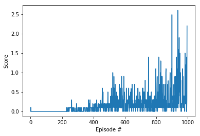

```python
# Instantiate the agent
agent = Agent(num_agents=num_agents, state_size=state_size, action_size=action_size,
              random_seed=0)

# Train the DDPG agent
scores = train_ddpg(agent, save_file='./checkpoints/initial')

# Plot the scores
plot_scores(scores)
```

#### Trial Runs

```python
# Try with tau of 1e-3
agent = Agent(num_agents=num_agents, state_size=state_size, action_size=action_size,
              random_seed=0)
scores = train_ddpg(agent, save_file='./checkpoints/trial_01')
plot_scores(scores)
```

```
Episode 20	Average score over the last 100 episodes: 0.01000
Episode 40	Average score over the last 100 episodes: 0.00500
Episode 60	Average score over the last 100 episodes: 0.00333
Episode 80	Average score over the last 100 episodes: 0.00250
Episode 100	Average score over the last 100 episodes: 0.00200
Episode 120	Average score over the last 100 episodes: 0.00000
Episode 140	Average score over the last 100 episodes: 0.00000
Episode 160	Average score over the last 100 episodes: 0.00000
Episode 180	Average score over the last 100 episodes: 0.00000
Episode 200	Average score over the last 100 episodes: 0.00000
Episode 220	Average score over the last 100 episodes: 0.00000
Episode 240	Average score over the last 100 episodes: 0.00000
Episode 260	Average score over the last 100 episodes: 0.00000
Episode 280	Average score over the last 100 episodes: 0.00000
Episode 300	Average score over the last 100 episodes: 0.00000
Episode 320	Average score over the last 100 episodes: 0.00000
Episode 340	Average score over the last 100 episodes: 0.00000
Episode 360	Average score over the last 100 episodes: 0.00000
Episode 380	Average score over the last 100 episodes: 0.00000
Episode 400	Average score over the last 100 episodes: 0.00000
Episode 420	Average score over the last 100 episodes: 0.00000
Episode 440	Average score over the last 100 episodes: 0.00000
Episode 460	Average score over the last 100 episodes: 0.00000
Episode 480	Average score over the last 100 episodes: 0.00000
Episode 500	Average score over the last 100 episodes: 0.00000
Episode 520	Average score over the last 100 episodes: 0.00000
Episode 540	Average score over the last 100 episodes: 0.00000
Episode 560	Average score over the last 100 episodes: 0.00000
Episode 580	Average score over the last 100 episodes: 0.00000
Episode 600	Average score over the last 100 episodes: 0.00000
Episode 620	Average score over the last 100 episodes: 0.00000
Episode 640	Average score over the last 100 episodes: 0.00000
Episode 660	Average score over the last 100 episodes: 0.00000
Episode 680	Average score over the last 100 episodes: 0.00000
Episode 700	Average score over the last 100 episodes: 0.00000
Episode 720	Average score over the last 100 episodes: 0.00000
Episode 740	Average score over the last 100 episodes: 0.00000
Episode 760	Average score over the last 100 episodes: 0.00000
Episode 780	Average score over the last 100 episodes: 0.00000
Episode 800	Average score over the last 100 episodes: 0.00000
```

[output cut: 123 more lines]

```
Episode 3280	Average score over the last 100 episodes: 0.00000
Episode 3300	Average score over the last 100 episodes: 0.00000
Episode 3320	Average score over the last 100 episodes: 0.00000
Episode 3340	Average score over the last 100 episodes: 0.00000
Episode 3360	Average score over the last 100 episodes: 0.00000
Episode 3380	Average score over the last 100 episodes: 0.00000
Episode 3400	Average score over the last 100 episodes: 0.00000
Episode 3420	Average score over the last 100 episodes: 0.00000
Episode 3440	Average score over the last 100 episodes: 0.00000
Episode 3460	Average score over the last 100 episodes: 0.00000
Episode 3480	Average score over the last 100 episodes: 0.00000
Episode 3500	Average score over the last 100 episodes: 0.00000
Episode 3520	Average score over the last 100 episodes: 0.00000
Episode 3540	Average score over the last 100 episodes: 0.00000
Episode 3550	Timestep 2	Current Score: 0.0000000
```

[output not shown]

```
Episode 20	Average score over the last 100 episodes: 0.01000
Episode 40	Average score over the last 100 episodes: 0.01700
Episode 60	Average score over the last 100 episodes: 0.02283
Episode 80	Average score over the last 100 episodes: 0.01963
Episode 100	Average score over the last 100 episodes: 0.02160
Episode 120	Average score over the last 100 episodes: 0.03750
Episode 140	Average score over the last 100 episodes: 0.06320
Episode 160	Average score over the last 100 episodes: 0.09300
Episode 180	Average score over the last 100 episodes: 0.11480
Episode 200	Average score over the last 100 episodes: 0.13460
Episode 220	Average score over the last 100 episodes: 0.15230
Episode 240	Average score over the last 100 episodes: 0.15550
Episode 260	Average score over the last 100 episodes: 0.15260
Episode 280	Average score over the last 100 episodes: 0.15550
Episode 300	Average score over the last 100 episodes: 0.15570
Episode 320	Average score over the last 100 episodes: 0.14000
Episode 340	Average score over the last 100 episodes: 0.13030
Episode 360	Average score over the last 100 episodes: 0.13910
Episode 380	Average score over the last 100 episodes: 0.17740
Episode 400	Average score over the last 100 episodes: 0.22350
Episode 420	Average score over the last 100 episodes: 0.27630
Episode 440	Average score over the last 100 episodes: 0.36310
Episode 460	Average score over the last 100 episodes: 0.38930
Episode 480	Average score over the last 100 episodes: 0.37110
Episode 500	Average score over the last 100 episodes: 0.34410
Episode 520	Average score over the last 100 episodes: 0.34120
Episode 540	Average score over the last 100 episodes: 0.30740
Episode 560	Average score over the last 100 episodes: 0.32550
Episode 580	Average score over the last 100 episodes: 0.36470
Episode 600	Average score over the last 100 episodes: 0.36070
Episode 620	Average score over the last 100 episodes: 0.40380
Episode 640	Average score over the last 100 episodes: 0.39880
Episode 660	Average score over the last 100 episodes: 0.41290
Episode 680	Average score over the last 100 episodes: 0.44180
Episode 700	Average score over the last 100 episodes: 0.48170
Episode 720	Average score over the last 100 episodes: 0.43780
Episode 740	Average score over the last 100 episodes: 0.44560
Episode 760	Average score over the last 100 episodes: 0.40150
Episode 780	Average score over the last 100 episodes: 0.46250
Episode 800	Average score over the last 100 episodes: 0.48160
Episode 820	Average score over the last 100 episodes: 0.51250

Environment solved in 820 episodes!	Average score over the last 100 episodes: 0.51250
```

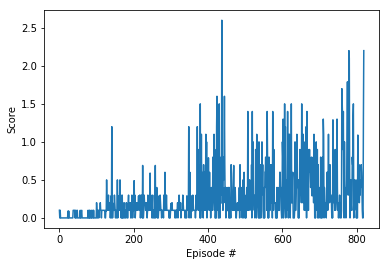

```python
# Try with tau of 1e-1
agent = Agent(num_agents=num_agents, state_size=state_size, action_size=action_size,
              random_seed=0)
scores = train_ddpg(agent, save_file='./checkpoints/trial_02')
plot_scores(scores)
```

```python
# Try with tau of 5e-1
agent = Agent(num_agents=num_agents, state_size=state_size, action_size=action_size,
              random_seed=0)
scores = train_ddpg(agent, save_file='./checkpoints/trial_03')
plot_scores(scores)
```

```
Episode 20	Average score over the last 100 episodes: 0.01000
Episode 40	Average score over the last 100 episodes: 0.00500
Episode 60	Average score over the last 100 episodes: 0.00333
Episode 80	Average score over the last 100 episodes: 0.00375
Episode 100	Average score over the last 100 episodes: 0.00600
Episode 120	Average score over the last 100 episodes: 0.00500
Episode 140	Average score over the last 100 episodes: 0.01190
Episode 160	Average score over the last 100 episodes: 0.01790
Episode 180	Average score over the last 100 episodes: 0.02970
Episode 200	Average score over the last 100 episodes: 0.05150
Episode 220	Average score over the last 100 episodes: 0.07420
Episode 240	Average score over the last 100 episodes: 0.10810
Episode 260	Average score over the last 100 episodes: 0.14670
Episode 280	Average score over the last 100 episodes: 0.18560
Episode 300	Average score over the last 100 episodes: 0.20660
Episode 320	Average score over the last 100 episodes: 0.23650
Episode 340	Average score over the last 100 episodes: 0.24140
Episode 360	Average score over the last 100 episodes: 0.24850
Episode 380	Average score over the last 100 episodes: 0.24780
Episode 400	Average score over the last 100 episodes: 0.26370
Episode 420	Average score over the last 100 episodes: 0.26880
Episode 440	Average score over the last 100 episodes: 0.26990
Episode 460	Average score over the last 100 episodes: 0.27000
Episode 480	Average score over the last 100 episodes: 0.27860
Episode 500	Average score over the last 100 episodes: 0.27150
Episode 520	Average score over the last 100 episodes: 0.27870
Episode 540	Average score over the last 100 episodes: 0.29490
Episode 560	Average score over the last 100 episodes: 0.28400
Episode 580	Average score over the last 100 episodes: 0.25840
Episode 600	Average score over the last 100 episodes: 0.24760
Episode 620	Average score over the last 100 episodes: 0.21250
Episode 640	Average score over the last 100 episodes: 0.21910
Episode 660	Average score over the last 100 episodes: 0.22800
Episode 680	Average score over the last 100 episodes: 0.25280
Episode 700	Average score over the last 100 episodes: 0.25300
Episode 720	Average score over the last 100 episodes: 0.28210
Episode 740	Average score over the last 100 episodes: 0.27330
Episode 760	Average score over the last 100 episodes: 0.29230
Episode 780	Average score over the last 100 episodes: 0.29520
Episode 800	Average score over the last 100 episodes: 0.29010
```

[output cut: 43 more lines]

```
Episode 1680	Average score over the last 100 episodes: 0.31010
Episode 1700	Average score over the last 100 episodes: 0.31110
Episode 1720	Average score over the last 100 episodes: 0.32720
Episode 1740	Average score over the last 100 episodes: 0.34740
Episode 1760	Average score over the last 100 episodes: 0.31440
Episode 1780	Average score over the last 100 episodes: 0.30970
Episode 1800	Average score over the last 100 episodes: 0.37050
Episode 1820	Average score over the last 100 episodes: 0.39250
Episode 1840	Average score over the last 100 episodes: 0.42230
Episode 1860	Average score over the last 100 episodes: 0.48030
Episode 1880	Average score over the last 100 episodes: 0.46530
Episode 1900	Average score over the last 100 episodes: 0.43950
Episode 1920	Average score over the last 100 episodes: 0.43420
Episode 1940	Average score over the last 100 episodes: 0.39020
Episode 1944	Timestep 134	Current Score: 0.30000
```

[output not shown]

[output cut: 8 more lines]

[output not shown]

```
Episode 20	Average score over the last 100 episodes: 0.01000
Episode 40	Average score over the last 100 episodes: 0.01200
Episode 60	Average score over the last 100 episodes: 0.01617
Episode 80	Average score over the last 100 episodes: 0.02338
Episode 100	Average score over the last 100 episodes: 0.03260
Episode 120	Average score over the last 100 episodes: 0.04940
Episode 140	Average score over the last 100 episodes: 0.06850
Episode 160	Average score over the last 100 episodes: 0.10450
Episode 180	Average score over the last 100 episodes: 0.12150
Episode 200	Average score over the last 100 episodes: 0.15530
Episode 220	Average score over the last 100 episodes: 0.18450
Episode 240	Average score over the last 100 episodes: 0.21740
Episode 260	Average score over the last 100 episodes: 0.22430
Episode 280	Average score over the last 100 episodes: 0.24310
Episode 300	Average score over the last 100 episodes: 0.22610
Episode 320	Average score over the last 100 episodes: 0.23080
Episode 340	Average score over the last 100 episodes: 0.21270
Episode 360	Average score over the last 100 episodes: 0.19770
Episode 380	Average score over the last 100 episodes: 0.20080
Episode 400	Average score over the last 100 episodes: 0.20790
Episode 420	Average score over the last 100 episodes: 0.18990
Episode 440	Average score over the last 100 episodes: 0.21020
Episode 460	Average score over the last 100 episodes: 0.22610
Episode 480	Average score over the last 100 episodes: 0.22920
Episode 500	Average score over the last 100 episodes: 0.33920
Episode 520	Average score over the last 100 episodes: 0.44530
Episode 534	Timestep 208	Current Score: 0.445000
Environment solved in 534 episodes!	Average score over the last 100 episodes: 0.50210
```

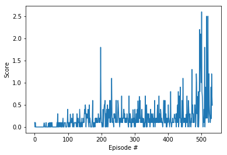

```python
# Try with tau of 3e-1
agent = Agent(num_agents=num_agents, state_size=state_size, action_size=action_size,
              random_seed=0)
scores = train_ddpg(agent, save_file='./checkpoints/trial_04')
plot_scores(scores)
```

```python
# Try with tau of 4e-1
agent = Agent(num_agents=num_agents, state_size=state_size, action_size=action_size,
              random_seed=0)
scores = train_ddpg(agent, save_file='./checkpoints/trial_05')
plot_scores(scores)
```

```
Episode 20	Average score over the last 100 episodes: 0.01000
Episode 40	Average score over the last 100 episodes: 0.00500
Episode 60	Average score over the last 100 episodes: 0.00667
Episode 80	Average score over the last 100 episodes: 0.01238
Episode 100	Average score over the last 100 episodes: 0.01480
Episode 120	Average score over the last 100 episodes: 0.02560
Episode 140	Average score over the last 100 episodes: 0.03730
Episode 160	Average score over the last 100 episodes: 0.05900
Episode 180	Average score over the last 100 episodes: 0.10190
Episode 200	Average score over the last 100 episodes: 0.14470
Episode 220	Average score over the last 100 episodes: 0.17450
Episode 240	Average score over the last 100 episodes: 0.18180
Episode 260	Average score over the last 100 episodes: 0.19410
Episode 280	Average score over the last 100 episodes: 0.19620
Episode 300	Average score over the last 100 episodes: 0.20650
Episode 320	Average score over the last 100 episodes: 0.21170
Episode 340	Average score over the last 100 episodes: 0.22660
Episode 360	Average score over the last 100 episodes: 0.23160
Episode 380	Average score over the last 100 episodes: 0.21750
Episode 400	Average score over the last 100 episodes: 0.20530
Episode 420	Average score over the last 100 episodes: 0.21720
Episode 440	Average score over the last 100 episodes: 0.24130
Episode 460	Average score over the last 100 episodes: 0.27500
Episode 480	Average score over the last 100 episodes: 0.30010
Episode 500	Average score over the last 100 episodes: 0.35310
Episode 520	Average score over the last 100 episodes: 0.37630
Episode 540	Average score over the last 100 episodes: 0.40900
Episode 560	Average score over the last 100 episodes: 0.41290
Episode 580	Average score over the last 100 episodes: 0.43170
Episode 600	Average score over the last 100 episodes: 0.39480
Episode 620	Average score over the last 100 episodes: 0.38150
Episode 640	Average score over the last 100 episodes: 0.37960
Episode 660	Average score over the last 100 episodes: 0.36360
Episode 680	Average score over the last 100 episodes: 0.35560
Episode 700	Average score over the last 100 episodes: 0.35360
Episode 720	Average score over the last 100 episodes: 0.34070
Episode 740	Average score over the last 100 episodes: 0.29190
Episode 760	Average score over the last 100 episodes: 0.30520
Episode 780	Average score over the last 100 episodes: 0.28210
Episode 800	Average score over the last 100 episodes: 0.25620
```

[output cut: 31 more lines]

```
Episode 1440	Average score over the last 100 episodes: 0.27690
Episode 1460	Average score over the last 100 episodes: 0.27060
Episode 1480	Average score over the last 100 episodes: 0.27940
Episode 1500	Average score over the last 100 episodes: 0.26370
Episode 1520	Average score over the last 100 episodes: 0.25160
Episode 1540	Average score over the last 100 episodes: 0.27160
Episode 1560	Average score over the last 100 episodes: 0.28080
Episode 1580	Average score over the last 100 episodes: 0.30580
Episode 1600	Average score over the last 100 episodes: 0.31780
Episode 1620	Average score over the last 100 episodes: 0.34570
Episode 1640	Average score over the last 100 episodes: 0.33700
Episode 1660	Average score over the last 100 episodes: 0.35520
Episode 1680	Average score over the last 100 episodes: 0.33230
Episode 1700	Average score over the last 100 episodes: 0.35420
Episode 1715	Timestep 112	Current Score: 0.20000
```

[output not shown]

```
Episode 20	Average score over the last 100 episodes: 0.01000
Episode 40	Average score over the last 100 episodes: 0.01225
Episode 60	Average score over the last 100 episodes: 0.01317
Episode 80	Average score over the last 100 episodes: 0.02363
Episode 100	Average score over the last 100 episodes: 0.02780
Episode 120	Average score over the last 100 episodes: 0.04980
Episode 140	Average score over the last 100 episodes: 0.07190
Episode 160	Average score over the last 100 episodes: 0.11160
Episode 180	Average score over the last 100 episodes: 0.15140
Episode 200	Average score over the last 100 episodes: 0.18230
Episode 220	Average score over the last 100 episodes: 0.20020
Episode 240	Average score over the last 100 episodes: 0.22490
Episode 260	Average score over the last 100 episodes: 0.25380
Episode 280	Average score over the last 100 episodes: 0.24170
Episode 300	Average score over the last 100 episodes: 0.28490
Episode 320	Average score over the last 100 episodes: 0.30380
Episode 340	Average score over the last 100 episodes: 0.36890
Episode 360	Average score over the last 100 episodes: 0.35100
Episode 380	Average score over the last 100 episodes: 0.41710
Episode 400	Average score over the last 100 episodes: 0.41110
Episode 420	Average score over the last 100 episodes: 0.46500
Episode 440	Average score over the last 100 episodes: 0.43710
Episode 460	Average score over the last 100 episodes: 0.46410
Episode 480	Average score over the last 100 episodes: 0.47630
Episode 500	Average score over the last 100 episodes: 0.47600
Episode 520	Average score over the last 100 episodes: 0.46420
Episode 540	Average score over the last 100 episodes: 0.47210
Episode 560	Average score over the last 100 episodes: 0.45420
Episode 580	Average score over the last 100 episodes: 0.44500
Episode 600	Average score over the last 100 episodes: 0.49590
Episode 601	Timestep 412	Current Score: 1.04500
Environment solved in 601 episodes!	Average score over the last 100 episodes: 0.50690
```

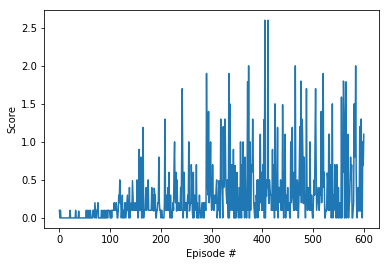

```python
# Try with tau of 2e-1
agent = Agent(num_agents=num_agents, state_size=state_size, action_size=action_size,
              random_seed=0)
scores = train_ddpg(agent, save_file='./checkpoints/trial_06')
plot_scores(scores)
```

```
Episode 20	Average score over the last 100 episodes: 0.01000
Episode 40	Average score over the last 100 episodes: 0.00500
Episode 60	Average score over the last 100 episodes: 0.00500
Episode 80	Average score over the last 100 episodes: 0.01125
Episode 100	Average score over the last 100 episodes: 0.01370
Episode 120	Average score over the last 100 episodes: 0.02360
Episode 140	Average score over the last 100 episodes: 0.02940
Episode 160	Average score over the last 100 episodes: 0.03820
Episode 180	Average score over the last 100 episodes: 0.04910
Episode 200	Average score over the last 100 episodes: 0.05790
Episode 220	Average score over the last 100 episodes: 0.07990
Episode 240	Average score over the last 100 episodes: 0.09950
Episode 260	Average score over the last 100 episodes: 0.11320
Episode 280	Average score over the last 100 episodes: 0.14030
Episode 300	Average score over the last 100 episodes: 0.15870
Episode 320	Average score over the last 100 episodes: 0.17450
Episode 340	Average score over the last 100 episodes: 0.24590
Episode 360	Average score over the last 100 episodes: 0.26110
Episode 380	Average score over the last 100 episodes: 0.25580
Episode 400	Average score over the last 100 episodes: 0.25850
Episode 420	Average score over the last 100 episodes: 0.26050
Episode 440	Average score over the last 100 episodes: 0.23150
Episode 460	Average score over the last 100 episodes: 0.24040
Episode 480	Average score over the last 100 episodes: 0.23510
Episode 500	Average score over the last 100 episodes: 0.23250
Episode 520	Average score over the last 100 episodes: 0.25160
Episode 540	Average score over the last 100 episodes: 0.28150
Episode 560	Average score over the last 100 episodes: 0.28660
Episode 580	Average score over the last 100 episodes: 0.29980
Episode 600	Average score over the last 100 episodes: 0.33750
Episode 620	Average score over the last 100 episodes: 0.32950
Episode 640	Average score over the last 100 episodes: 0.37270
Episode 660	Average score over the last 100 episodes: 0.40100
Episode 680	Average score over the last 100 episodes: 0.45730
Episode 700	Average score over the last 100 episodes: 0.49050
Episode 702	Timestep 566	Current Score: 1.44500
Environment solved in 702 episodes!	Average score over the last 100 episodes: 0.50260
```

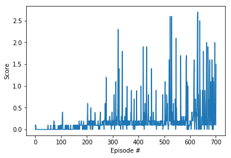

```python
# Try with batch size of 256
# Set to tau of 3e-1
agent = Agent(num_agents=num_agents, state_size=state_size, action_size=action_size,
              random_seed=0)
scores = train_ddpg(agent, save_file='./checkpoints/trial_07')
plot_scores(scores)
```

```
Episode 20	Average score over the last 100 episodes: 0.01000
Episode 40	Average score over the last 100 episodes: 0.00500
Episode 60	Average score over the last 100 episodes: 0.00333
Episode 80	Average score over the last 100 episodes: 0.00250
Episode 100	Average score over the last 100 episodes: 0.00200
Episode 120	Average score over the last 100 episodes: 0.00000
Episode 140	Average score over the last 100 episodes: 0.00000
Episode 160	Average score over the last 100 episodes: 0.00000
Episode 180	Average score over the last 100 episodes: 0.00000
Episode 200	Average score over the last 100 episodes: 0.00380
Episode 220	Average score over the last 100 episodes: 0.00380
Episode 240	Average score over the last 100 episodes: 0.00380
Episode 260	Average score over the last 100 episodes: 0.00380
Episode 280	Average score over the last 100 episodes: 0.00750
Episode 300	Average score over the last 100 episodes: 0.00760
Episode 320	Average score over the last 100 episodes: 0.01360
Episode 340	Average score over the last 100 episodes: 0.02060
Episode 360	Average score over the last 100 episodes: 0.03150
Episode 380	Average score over the last 100 episodes: 0.06740
Episode 400	Average score over the last 100 episodes: 0.11240
Episode 420	Average score over the last 100 episodes: 0.16330
Episode 440	Average score over the last 100 episodes: 0.22730
Episode 460	Average score over the last 100 episodes: 0.25130
Episode 480	Average score over the last 100 episodes: 0.24370
Episode 500	Average score over the last 100 episodes: 0.27170
Episode 520	Average score over the last 100 episodes: 0.28470
Episode 540	Average score over the last 100 episodes: 0.36540
Episode 560	Average score over the last 100 episodes: 0.46040
Episode 564	Timestep 396	Current Score: 0.99500
Environment solved in 564 episodes!	Average score over the last 100 episodes: 0.50140
```

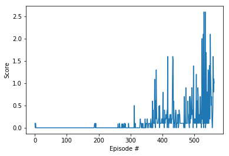

```python
# Try with batch size of 512
# Set to tau of 3e-1
agent = Agent(num_agents=num_agents, state_size=state_size, action_size=action_size,
              random_seed=0)
scores = train_ddpg(agent, save_file='./checkpoints/trial_08')
plot_scores(scores)
```

```
Episode 20	Average score over the last 100 episodes: 0.01000
Episode 40	Average score over the last 100 episodes: 0.01000
Episode 60	Average score over the last 100 episodes: 0.00667
Episode 80	Average score over the last 100 episodes: 0.00500
Episode 100	Average score over the last 100 episodes: 0.00400
Episode 120	Average score over the last 100 episodes: 0.00390
Episode 140	Average score over the last 100 episodes: 0.00990
Episode 160	Average score over the last 100 episodes: 0.02690
Episode 180	Average score over the last 100 episodes: 0.06690
Episode 200	Average score over the last 100 episodes: 0.10670
Episode 220	Average score over the last 100 episodes: 0.13460
Episode 240	Average score over the last 100 episodes: 0.15900
Episode 260	Average score over the last 100 episodes: 0.16200
Episode 280	Average score over the last 100 episodes: 0.14750
Episode 300	Average score over the last 100 episodes: 0.14070
Episode 320	Average score over the last 100 episodes: 0.15670
Episode 340	Average score over the last 100 episodes: 0.17220
Episode 360	Average score over the last 100 episodes: 0.21200
Episode 380	Average score over the last 100 episodes: 0.20840
Episode 400	Average score over the last 100 episodes: 0.20040
Episode 420	Average score over the last 100 episodes: 0.20350
Episode 440	Average score over the last 100 episodes: 0.21260
Episode 460	Average score over the last 100 episodes: 0.21470
Episode 480	Average score over the last 100 episodes: 0.28680
Episode 500	Average score over the last 100 episodes: 0.35380
Episode 520	Average score over the last 100 episodes: 0.42090
Episode 540	Average score over the last 100 episodes: 0.44390
Episode 560	Average score over the last 100 episodes: 0.46090
Episode 571	Timestep 291	Current Score: 0.745000
Environment solved in 571 episodes!	Average score over the last 100 episodes: 0.50090
```

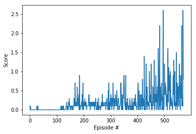

```python
# Try with batch size of 1024
# Set to tau of 3e-1
agent = Agent(num_agents=num_agents, state_size=state_size, action_size=action_size,
              random_seed=0)
scores = train_ddpg(agent, save_file='./checkpoints/trial_09')
plot_scores(scores)
```

```python
# Try with batch size of 64
# Set to tau of 3e-1
agent = Agent(num_agents=num_agents, state_size=state_size, action_size=action_size,
              random_seed=0)
scores = train_ddpg(agent, save_file='./checkpoints/trial_10')
plot_scores(scores)
```

```
Episode 20	Average score over the last 100 episodes: 0.00500
Episode 40	Average score over the last 100 episodes: 0.00250
Episode 60	Average score over the last 100 episodes: 0.00317
Episode 80	Average score over the last 100 episodes: 0.00738
Episode 100	Average score over the last 100 episodes: 0.00890
Episode 120	Average score over the last 100 episodes: 0.01290
Episode 140	Average score over the last 100 episodes: 0.01290
Episode 160	Average score over the last 100 episodes: 0.01300
Episode 180	Average score over the last 100 episodes: 0.01300
Episode 200	Average score over the last 100 episodes: 0.02280
Episode 220	Average score over the last 100 episodes: 0.02270
Episode 240	Average score over the last 100 episodes: 0.04240
Episode 260	Average score over the last 100 episodes: 0.06920
Episode 280	Average score over the last 100 episodes: 0.08090
Episode 300	Average score over the last 100 episodes: 0.10160
Episode 320	Average score over the last 100 episodes: 0.12460
Episode 340	Average score over the last 100 episodes: 0.13190
Episode 360	Average score over the last 100 episodes: 0.12610
Episode 380	Average score over the last 100 episodes: 0.13820
Episode 400	Average score over the last 100 episodes: 0.13750
Episode 420	Average score over the last 100 episodes: 0.14540
Episode 440	Average score over the last 100 episodes: 0.14710
Episode 460	Average score over the last 100 episodes: 0.15200
Episode 480	Average score over the last 100 episodes: 0.15000
Episode 500	Average score over the last 100 episodes: 0.14870
Episode 520	Average score over the last 100 episodes: 0.14960
Episode 540	Average score over the last 100 episodes: 0.15290
Episode 560	Average score over the last 100 episodes: 0.15590
Episode 580	Average score over the last 100 episodes: 0.16600
Episode 600	Average score over the last 100 episodes: 0.16630
Episode 620	Average score over the last 100 episodes: 0.15440
Episode 640	Average score over the last 100 episodes: 0.15820
Episode 660	Average score over the last 100 episodes: 0.15130
Episode 680	Average score over the last 100 episodes: 0.13610
Episode 700	Average score over the last 100 episodes: 0.13810
Episode 720	Average score over the last 100 episodes: 0.14620
Episode 740	Average score over the last 100 episodes: 0.14720
Episode 760	Average score over the last 100 episodes: 0.16590
Episode 780	Average score over the last 100 episodes: 0.18400
Episode 800	Average score over the last 100 episodes: 0.18190
Episode 820	Average score over the last 100 episodes: 0.17500
Episode 840	Average score over the last 100 episodes: 0.17200
Episode 860	Average score over the last 100 episodes: 0.15890
Episode 880	Average score over the last 100 episodes: 0.15180
Episode 900	Average score over the last 100 episodes: 0.15200
Episode 920	Average score over the last 100 episodes: 0.14680
Episode 940	Average score over the last 100 episodes: 0.14360
Episode 960	Average score over the last 100 episodes: 0.14380
Episode 980	Average score over the last 100 episodes: 0.14780
Episode 1000	Average score over the last 100 episodes: 0.13960
Episode 1004	Timestep 73	Current Score: 0.150000
```

[output not shown]

```python
# Try with actor learning rate of 1e-3
# Set to tau of 3e-1
agent = Agent(num_agents=num_agents, state_size=state_size, action_size=action_size,
              random_seed=0)
scores = train_ddpg(agent, save_file='./checkpoints/trial_11')
plot_scores(scores)
```

```
Episode 20	Average score over the last 100 episodes: 0.01000
Episode 40	Average score over the last 100 episodes: 0.00500
Episode 60	Average score over the last 100 episodes: 0.00333
Episode 80	Average score over the last 100 episodes: 0.00250
Episode 100	Average score over the last 100 episodes: 0.00200
Episode 120	Average score over the last 100 episodes: 0.00000
Episode 140	Average score over the last 100 episodes: 0.00000
Episode 160	Average score over the last 100 episodes: 0.00000
Episode 180	Average score over the last 100 episodes: 0.00000
Episode 200	Average score over the last 100 episodes: 0.00000
Episode 220	Average score over the last 100 episodes: 0.00000
Episode 240	Average score over the last 100 episodes: 0.00000
Episode 260	Average score over the last 100 episodes: 0.00000
Episode 280	Average score over the last 100 episodes: 0.00000
Episode 300	Average score over the last 100 episodes: 0.00000
Episode 320	Average score over the last 100 episodes: 0.00000
Episode 340	Average score over the last 100 episodes: 0.00000
Episode 360	Average score over the last 100 episodes: 0.00000
Episode 380	Average score over the last 100 episodes: 0.00000
Episode 400	Average score over the last 100 episodes: 0.00000
Episode 420	Average score over the last 100 episodes: 0.00000
Episode 440	Average score over the last 100 episodes: 0.00000
Episode 460	Average score over the last 100 episodes: 0.00000
Episode 480	Average score over the last 100 episodes: 0.00000
Episode 500	Average score over the last 100 episodes: 0.00000
Episode 520	Average score over the last 100 episodes: 0.00000
Episode 540	Average score over the last 100 episodes: 0.00000
Episode 560	Average score over the last 100 episodes: 0.00000
Episode 580	Average score over the last 100 episodes: 0.00000
Episode 600	Average score over the last 100 episodes: 0.00000
Episode 620	Average score over the last 100 episodes: 0.00000
Episode 640	Average score over the last 100 episodes: 0.00000
Episode 660	Average score over the last 100 episodes: 0.00000
Episode 680	Average score over the last 100 episodes: 0.00000
Episode 700	Average score over the last 100 episodes: 0.00000
Episode 720	Average score over the last 100 episodes: 0.00000
Episode 740	Average score over the last 100 episodes: 0.00000
Episode 760	Average score over the last 100 episodes: 0.00000
Episode 780	Average score over the last 100 episodes: 0.00000
Episode 800	Average score over the last 100 episodes: 0.00000
Episode 820	Average score over the last 100 episodes: 0.00000
Episode 840	Average score over the last 100 episodes: 0.00000
Episode 860	Average score over the last 100 episodes: 0.00000
Episode 880	Average score over the last 100 episodes: 0.00000
Episode 900	Average score over the last 100 episodes: 0.00000
Episode 920	Average score over the last 100 episodes: 0.00000
Episode 940	Average score over the last 100 episodes: 0.00000
Episode 960	Average score over the last 100 episodes: 0.00000
Episode 980	Average score over the last 100 episodes: 0.00000
Episode 1000	Average score over the last 100 episodes: 0.00000
Episode 1020	Average score over the last 100 episodes: 0.00000
Episode 1031	Timestep 9	Current Score: 0.0000000
```

[output not shown]

```python
# Try with actor learning rate of 1e-2 and critic learning rate of 1e-2
# Set to tau of 3e-1
agent = Agent(num_agents=num_agents, state_size=state_size, action_size=action_size,
              random_seed=0)
scores = train_ddpg(agent, save_file='./checkpoints/trial_12')
plot_scores(scores)
```

```
Episode 20	Average score over the last 100 episodes: 0.01000
Episode 40	Average score over the last 100 episodes: 0.00500
Episode 60	Average score over the last 100 episodes: 0.00333
Episode 80	Average score over the last 100 episodes: 0.00250
Episode 100	Average score over the last 100 episodes: 0.00200
Episode 120	Average score over the last 100 episodes: 0.00000
Episode 140	Average score over the last 100 episodes: 0.00000
Episode 160	Average score over the last 100 episodes: 0.00000
Episode 180	Average score over the last 100 episodes: 0.00000
Episode 200	Average score over the last 100 episodes: 0.00000
Episode 220	Average score over the last 100 episodes: 0.00000
Episode 240	Average score over the last 100 episodes: 0.00000
Episode 260	Average score over the last 100 episodes: 0.00000
Episode 280	Average score over the last 100 episodes: 0.00000
Episode 300	Average score over the last 100 episodes: 0.00000
Episode 320	Average score over the last 100 episodes: 0.00000
Episode 340	Average score over the last 100 episodes: 0.00000
Episode 360	Average score over the last 100 episodes: 0.00000
Episode 380	Average score over the last 100 episodes: 0.00000
Episode 400	Average score over the last 100 episodes: 0.00000
Episode 420	Average score over the last 100 episodes: 0.00000
Episode 440	Average score over the last 100 episodes: 0.00000
Episode 460	Average score over the last 100 episodes: 0.00000
Episode 480	Average score over the last 100 episodes: 0.00000
Episode 500	Average score over the last 100 episodes: 0.00000
Episode 520	Average score over the last 100 episodes: 0.00000
Episode 540	Average score over the last 100 episodes: 0.00000
Episode 560	Average score over the last 100 episodes: 0.00000
Episode 580	Average score over the last 100 episodes: 0.00000
Episode 600	Average score over the last 100 episodes: 0.00000
Episode 620	Average score over the last 100 episodes: 0.00000
Episode 640	Average score over the last 100 episodes: 0.00000
Episode 660	Average score over the last 100 episodes: 0.00000
Episode 680	Average score over the last 100 episodes: 0.00000
Episode 700	Average score over the last 100 episodes: 0.00000
Episode 720	Average score over the last 100 episodes: 0.00000
Episode 740	Average score over the last 100 episodes: 0.00000
Episode 760	Average score over the last 100 episodes: 0.00000
Episode 780	Average score over the last 100 episodes: 0.00000
Episode 800	Average score over the last 100 episodes: 0.00000
```

[output cut: 36 more lines]

```
Episode 1540	Average score over the last 100 episodes: 0.00000
Episode 1560	Average score over the last 100 episodes: 0.00000
Episode 1580	Average score over the last 100 episodes: 0.00000
Episode 1600	Average score over the last 100 episodes: 0.00000
Episode 1620	Average score over the last 100 episodes: 0.00000
Episode 1640	Average score over the last 100 episodes: 0.00000
Episode 1660	Average score over the last 100 episodes: 0.00000
Episode 1680	Average score over the last 100 episodes: 0.00000
Episode 1700	Average score over the last 100 episodes: 0.00000
Episode 1720	Average score over the last 100 episodes: 0.00000
Episode 1740	Average score over the last 100 episodes: 0.00000
Episode 1760	Average score over the last 100 episodes: 0.00000
Episode 1780	Average score over the last 100 episodes: 0.00000
Episode 1800	Average score over the last 100 episodes: 0.00000
Episode 1807	Timestep 4	Current Score: 0.0000000
```

[output not shown]

```
Episode 20	Average score over the last 100 episodes: 0.01000
Episode 40	Average score over the last 100 episodes: 0.00725
Episode 60	Average score over the last 100 episodes: 0.00967
Episode 80	Average score over the last 100 episodes: 0.01475
Episode 100	Average score over the last 100 episodes: 0.01860
Episode 120	Average score over the last 100 episodes: 0.03610
Episode 140	Average score over the last 100 episodes: 0.05020
Episode 160	Average score over the last 100 episodes: 0.06220
Episode 180	Average score over the last 100 episodes: 0.09500
Episode 200	Average score over the last 100 episodes: 0.13000
Episode 220	Average score over the last 100 episodes: 0.14640
Episode 240	Average score over the last 100 episodes: 0.17030
Episode 260	Average score over the last 100 episodes: 0.19330
Episode 280	Average score over the last 100 episodes: 0.18710
Episode 300	Average score over the last 100 episodes: 0.14930
Episode 320	Average score over the last 100 episodes: 0.15630
Episode 340	Average score over the last 100 episodes: 0.16920
Episode 360	Average score over the last 100 episodes: 0.19420
Episode 380	Average score over the last 100 episodes: 0.22330
Episode 400	Average score over the last 100 episodes: 0.29810
Episode 420	Average score over the last 100 episodes: 0.36510
Episode 440	Average score over the last 100 episodes: 0.41400
Episode 457	Timestep 1000	Current Score: 2.55000
Environment solved in 457 episodes!	Average score over the last 100 episodes: 0.51080
```

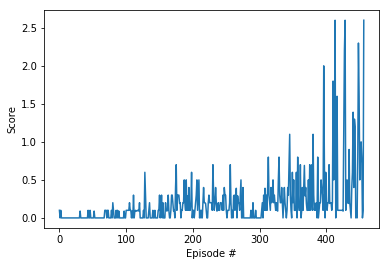

```python
# Try with critic learning rate of 1e-4
# Set to tau of 3e-1
agent = Agent(num_agents=num_agents, state_size=state_size, action_size=action_size,
              random_seed=0)
scores = train_ddpg(agent, save_file='./checkpoints/trial_13')
plot_scores(scores)
```

```python
# Try with actor learning rate of 5e-5 and critic learning rate of 5e-5
# Set to tau of 3e-1
agent = Agent(num_agents=num_agents, state_size=state_size, action_size=action_size,
              random_seed=0)
scores = train_ddpg(agent, save_file='./checkpoints/trial_14')
plot_scores(scores)
```

```
Episode 20	Average score over the last 100 episodes: 0.01000
Episode 40	Average score over the last 100 episodes: 0.01000
Episode 60	Average score over the last 100 episodes: 0.01317
Episode 80	Average score over the last 100 episodes: 0.01238
Episode 100	Average score over the last 100 episodes: 0.01090
Episode 120	Average score over the last 100 episodes: 0.00990
Episode 140	Average score over the last 100 episodes: 0.00790
Episode 160	Average score over the last 100 episodes: 0.00590
Episode 180	Average score over the last 100 episodes: 0.00970
Episode 200	Average score over the last 100 episodes: 0.01060
Episode 220	Average score over the last 100 episodes: 0.01460
Episode 240	Average score over the last 100 episodes: 0.01860
Episode 260	Average score over the last 100 episodes: 0.02330
Episode 280	Average score over the last 100 episodes: 0.02520
Episode 300	Average score over the last 100 episodes: 0.02910
Episode 320	Average score over the last 100 episodes: 0.03770
Episode 340	Average score over the last 100 episodes: 0.04620
Episode 360	Average score over the last 100 episodes: 0.05250
Episode 380	Average score over the last 100 episodes: 0.05460
Episode 400	Average score over the last 100 episodes: 0.06060
Episode 420	Average score over the last 100 episodes: 0.06560
Episode 440	Average score over the last 100 episodes: 0.07600
Episode 460	Average score over the last 100 episodes: 0.08600
Episode 480	Average score over the last 100 episodes: 0.10700
Episode 500	Average score over the last 100 episodes: 0.12280
Episode 520	Average score over the last 100 episodes: 0.13670
Episode 540	Average score over the last 100 episodes: 0.15980
Episode 560	Average score over the last 100 episodes: 0.16780
Episode 580	Average score over the last 100 episodes: 0.18870
Episode 600	Average score over the last 100 episodes: 0.26090
Episode 612	Timestep 24	Current Score: 0.050000
```

[output not shown]

#### Final Run

```python
# Set to critic learning rate of 1e-4
# Set to tau of 3e-1
agent = Agent(num_agents=num_agents, state_size=state_size, action_size=action_size,
              random_seed=0)
scores = train_ddpg(agent, save_file='./checkpoints/final_model')
```

```
Episode 20	Average score over the last 100 episodes: 0.01000
Episode 40	Average score over the last 100 episodes: 0.00725
Episode 60	Average score over the last 100 episodes: 0.00967
Episode 80	Average score over the last 100 episodes: 0.01475
Episode 100	Average score over the last 100 episodes: 0.01860
Episode 120	Average score over the last 100 episodes: 0.03610
Episode 140	Average score over the last 100 episodes: 0.05020
Episode 160	Average score over the last 100 episodes: 0.06220
Episode 180	Average score over the last 100 episodes: 0.09500
Episode 200	Average score over the last 100 episodes: 0.13000
Episode 220	Average score over the last 100 episodes: 0.14640
Episode 240	Average score over the last 100 episodes: 0.17030
Episode 260	Average score over the last 100 episodes: 0.19330
Episode 280	Average score over the last 100 episodes: 0.18710
Episode 300	Average score over the last 100 episodes: 0.14930
Episode 320	Average score over the last 100 episodes: 0.15630
Episode 340	Average score over the last 100 episodes: 0.16920
Episode 360	Average score over the last 100 episodes: 0.19420
Episode 380	Average score over the last 100 episodes: 0.22330
Episode 400	Average score over the last 100 episodes: 0.29810
Episode 420	Average score over the last 100 episodes: 0.36510
Episode 440	Average score over the last 100 episodes: 0.41400
Episode 457	Timestep 1000	Current Score: 2.55000
Environment solved in 457 episodes!	Average score over the last 100 episodes: 0.51080
```

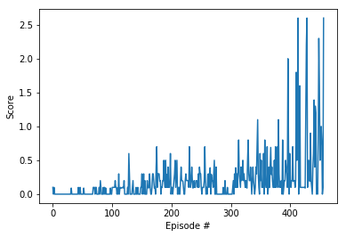

```python
plot_scores(scores)
```